# A3: SPL Library Checkouts

### Introduction

The dataset I choose to use contains book that has percy jackson in its title. I choose to analyze this data because a long time ago I thought reading Harry Potter is too mainstream and I wanted to try something different and choose to read Percy Jackson. I should’ve sticked with Harry Potter… Well because of that I choose to analyze this series. I will analyze the trends and popularity of the Percy Jackson series, as well as individual book performance within the series. Specifically, I will be analyzing the checkout data of the series from the Seattle public library to determine which books are the most popular, which books have the highest and lowest number of checkouts, and whether there are any trends in terms of when the books are checked out throughout the year.

### Summary Information

After analyzing the library’s checkout data, several key findings were discovered. The total number of checkouts for all items was 48123, with the most common checkout being for the book titled ‘Percy Jackson & the Olympians [videorecording]’. On average, there were 9.8 checkouts per activity per year. The most popular material type was ‘EBOOK’, with 15407 checkouts. The peak checkout month for each year was determined, with the highest number of checkouts in a month occurring in the year 2021. Finally, the lowest checkout year and month were identified, with the fewest checkouts occurring multiple times at different month of the year 2005 until 2008. These findings provide valuable insights into the library’s usage patterns and can inform future collection development and resource allocation decisions.

### The Dataset

The Checkouts by Title dataset on the Seattle Open Data portal was collected and published by the Seattle Public Library. The dataset contains information on the usage of books and other materials in the library system between 2005 and present. Parameters included in the dataset are usage class, checkout type, material type, checkout year, checkout month, number of checkouts, title, ISBN, creator, subjects, publisher, and publication year. The data was collected electronically by the circulation software used by the library system when patrons check out and return materials. The purpose of the data collection was to provide insight into library operations, including resource allocation and collection development decisions. However, ethical considerations must be taken into account when working with this data, including ensuring the privacy and confidentiality of library patrons and minimizing the potential impact on individuals and the community. Limitations of the dataset include the fact that it only reflects usage within the Seattle Public Library system and does not provide a complete picture of book usage in the community. Additionally, it only includes information on materials that are part of the library’s collection and does not include usage information on other types of materials or digital downloads. Finally, the dataset is limited to checkouts, and does not provide information on other types of usage, such as in-library use. These limitations and ethical considerations must be taken into account when analyzing and interpreting the Checkouts by Title dataset.

### First Trends Over Time Chart

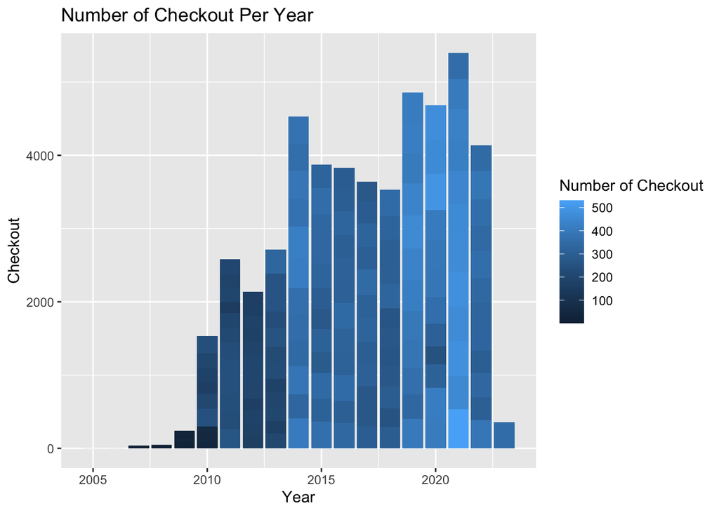

The chart displays the number of checkouts per year. I included this chart so that we can know how the number of chekcout changes every year as I wanted to know the activity of the library. The x-axis represents the years from 2005 to 2023, while the y-axis shows the total number of checkouts for each year. The bars are colored according to the total number of checkouts for each month, with darker colors representing lower numbers of checkouts and lighter color representing more checkouts.

### Second Trends Over Time Chart

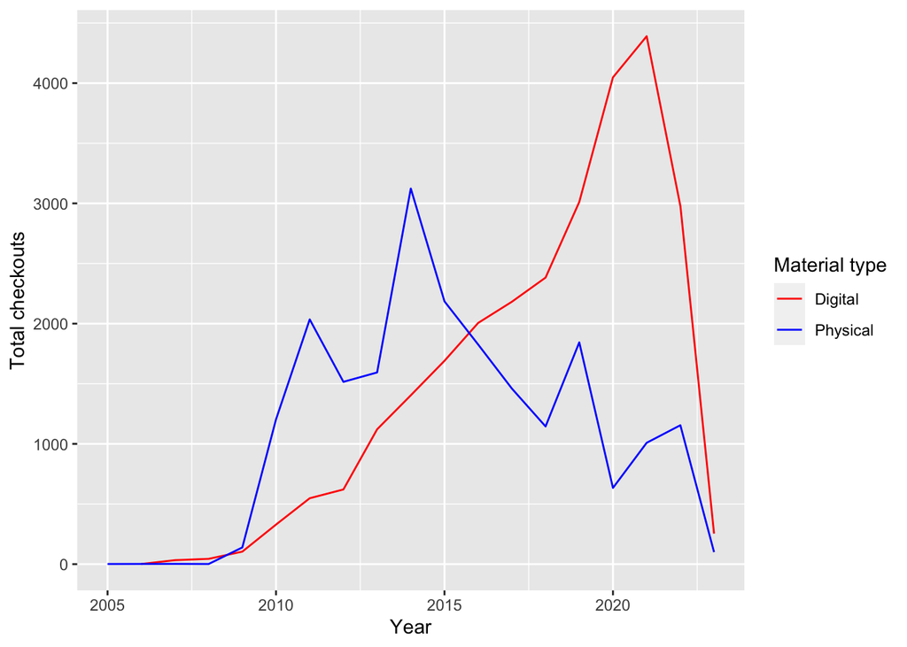

The chart displays the total number of checkouts per year for physical and digital usage class in the Seattle Public Library system. I included this chart as I wanted to see how digital goods are doing compared to physical goods. Honestly, I wanted to know whether there are people who is still checking out physical stuffs from library. The x-axis represents the years from 2005 to 2023, while the y-axis shows the total number of checkouts for each year. The two lines are colored according to the material type, with blue representing physical materials and red representing digital materials.

### Your Choice

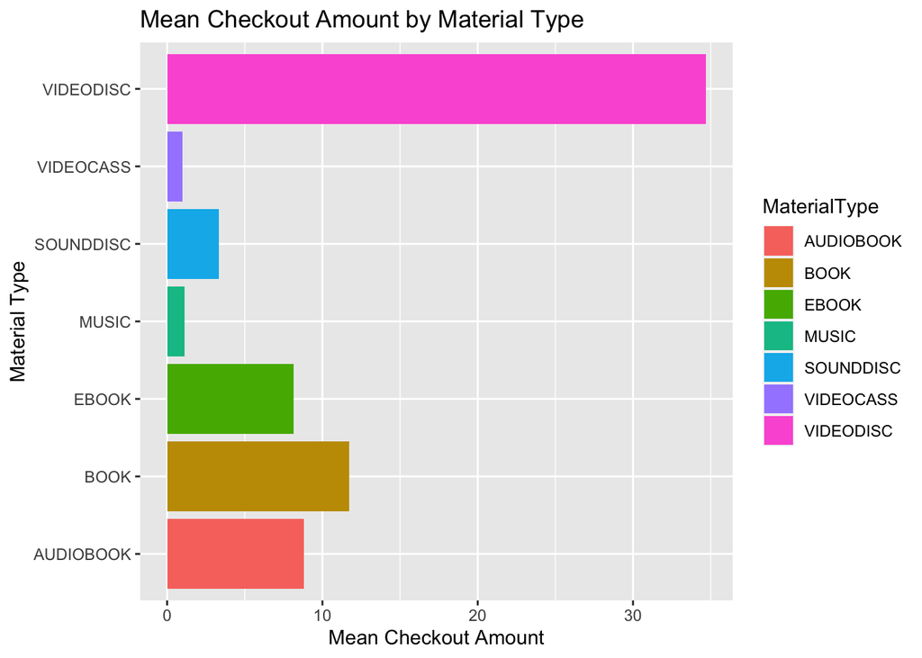

The chart displays the mean checkout amount for each material type in the Seattle Public Library system. I included this chart as I was curious on which type of material are checked out the most. I was surprised that VIDEODISC was the most common checkout. The x-axis represents the mean checkout amount for each material typet, while the y-axis shows the material types. The bars are colored according to the material type.